# Assignment 1

In this assignment you will

- download the dataset
- split the data
- write dataloader class that reads the images and applies augmentation.

Read the comments carefully and insert your code where you see:  
**##### START OF YOUR CODE #####**  
**##### END OF YOUR CODE #####**  
or for the inline codes you will see  
**##### INSERT YOUR CODE HERE #####**

### 1. Download Data

You will use the [COVID-19 CT dataset](https://www.kaggle.com/datasets/maedemaftouni/large-covid19-ct-slice-dataset?select=meta_data_cap.csv) for this assignment. You may create an account on Kaggle and follow [the steps below taken from Kaggle's website](https://www.kaggle.com/general/74235) for easy download (Option 1) or simply download the dataset in your computer and upload it to your Google Drive (Option 2).  
Option 2 is much slower although straightforward.

```python
!pip install -q kaggle
```

```python
# Go to your account on Kaggle, scroll to API section and click "Create New API Token" to download "kaggle.json" file to your computer.
# IMPORTANT: you need to click "Expire API Token" to remove previous tokens before creating a new one if you have previously created an API token.
# Run this cell and choose the kaggle.json file that you downloaded
from google.colab import files
files.upload()
```

Upload widget is only available when the cell has been executed in the current browser session. Please rerun this cell to enable.

```
Saving kaggle.json to kaggle (2).json
```

```
{'kaggle (2).json': b'{"username":"fatmanuryaman","key":"1ca564f82f62cf995f5928c2429ee7a0"}'}
```

```python
#Make directory named kaggle and copy kaggle.json file there.
!mkdir ~/.kaggle
!cp kaggle.json ~/.kaggle/
```

```
mkdir: cannot create directory ‘/root/.kaggle’: File exists
```

```python
#Change the permissions
!chmod 600 ~/.kaggle/kaggle.json
```

```python
#Download the dataset
!kaggle datasets download -d 'maedemaftouni/large-covid19-ct-slice-dataset'
```

```
large-covid19-ct-slice-dataset.zip: Skipping, found more recently modified local copy (use --force to force download)
```

### 2. Unzip the data

```python
import shutil

shutil.unpack_archive("/content/large-covid19-ct-slice-dataset.zip", "/tmp/")
```

### 3. Data Investigation

The data consists of computerized tomography (CT) images from 3 patient groups: * Healthy controls * Covid-19 patients * Patients with community-acquired pneumonia (CAP) Let's read the meta files to compute the number of patients in each group. After this step we will exclude CAP patients as the data size is very small.

```python
import pandas as pd

meta_normal = pd.read_csv("/tmp/meta_data_normal.csv")
meta_covid = pd.read_csv("/tmp/meta_data_covid.csv", encoding='windows-1252')
meta_cap = pd.read_csv("/tmp/meta_data_cap.csv")

# Define the variables below using meta dataframes

normal_pt_nb = len(meta_normal["Patient ID"].unique())# Number of patients in normal group
covid_pt_nb = len(meta_covid["Patient ID"].unique())# Number of patients in covid group
cap_pt_nb = len(meta_cap["Patient ID"].unique()) # Number of patients in CAP group

normal_img_nb = len(meta_normal) # Number of images in normal group
covid_img_nb = len(meta_covid)# Number of images in covid group
cap_img_nb = len(meta_cap) # Number of images in CAP group


print("Normal")
print("Number of patient: ", normal_pt_nb)
print("Number of image: ", normal_img_nb)

print("\nCovid")
print("Number of patient: ", covid_pt_nb)
print("Number of image: ", covid_img_nb)

print("\nCAP")
print("Number of patient: ", cap_pt_nb)
print("Number of image: ", cap_img_nb)
```

```
Normal
Number of patient:  604
Number of image:  6893

Covid
Number of patient:  464
Number of image:  7593

CAP
Number of patient:  54
Number of image:  2618
```

### 4. Splitting

We will split the train, validation and test sets as 30% - 20% - 50%. At the end of this step you should have 4 lists named:

- normal_val_file_list,
- normal_test_file_list,
- covid_val_file_list
- covid_test_file_list

corresponding to the lists of filenames for validation and test sets in normal and covid group.  
IMPORTANT: We must do the splitting on patient level to avoid data leakage. You can see the effect of splitting on data leakage in [this article](https://www.nature.com/articles/s41598-021-01681-w#Sec2) (check Table 4).

```python
import numpy as np

# Set seed to get the same result (I specifically chose this seed after a couple of tries so that we'll have approximately same split ratios on slice level as well)
np.random.seed(58)
val_split_size = .2
test_split_size = .5

normal_val_file_list, normal_test_file_list = [], []
covid_val_file_list, covid_test_file_list = [], []
##### START OF YOUR CODE #####
#Normal Patients Groupped By Their ID's.
normal_pt_id_dict = {}
normal_pt_id_list = meta_normal["Patient ID"]
index_list = [i for i in range(len(meta_normal))]
for patient_id, index in zip(normal_pt_id_list,index_list):
  if patient_id not in normal_pt_id_dict:
    normal_pt_id_dict[patient_id] = []
  normal_pt_id_dict[patient_id].append(index)
normal_pt_id_groupped = {key: values for key, *values in normal_pt_id_dict.items()}

#Shuffle the list of ID's
shuffled_keys = list(normal_pt_id_groupped.keys())
np.random.shuffle(shuffled_keys)
#Groupped the photos according to ID's.
patient_data = [normal_pt_id_groupped[key] for key in shuffled_keys]

#Determine the size of validation and test sets in terms of photos.
normal_val_size = int(val_split_size*normal_pt_nb)
normal_test_size = int(test_split_size*normal_pt_nb)

#Slicing the validation set a list.
normal_pt_val_data = patient_data[:normal_val_size]
normal_val_file_list_id = []
for i in normal_pt_val_data:
  for j in i:
    for n in j:
      normal_val_file_list_id.append(n)

#Slicing the test set and make a list.
normal_pt_test_data = patient_data[normal_val_size:normal_val_size+normal_test_size]
normal_test_file_list_id = []
for i in normal_pt_test_data:
  for j in i:
    for n in j:
      normal_test_file_list_id.append(n)

#Taking the filenames and convert them to lists.
normal_val_file_list = meta_normal["File name"].iloc[normal_val_file_list_id].values.tolist()
normal_test_file_list = meta_normal["File name"].iloc[normal_test_file_list_id].values.tolist()
#Slicing the train set.
normal_train_file_list_id = normal_val_file_list_id + normal_test_file_list_id
normal_train_file_list = meta_normal["File name"].drop(normal_train_file_list_id).values.tolist()


#Covid Patients Groupped By Their ID's.
covid_pt_id_dict = {}
covid_pt_id_list = meta_covid["Patient ID"]
index_list = [i for i in range(len(meta_covid))]
for patient_id, index in zip(covid_pt_id_list,index_list):
  if patient_id not in covid_pt_id_dict:
    covid_pt_id_dict[patient_id] = []
  covid_pt_id_dict[patient_id].append(index)
covid_pt_id_groupped = {key: values for key, *values in covid_pt_id_dict.items()}

#Shuffle the list of ID's
shuffled_keys = list(covid_pt_id_groupped.keys())
np.random.shuffle(shuffled_keys)
patient_data = [covid_pt_id_groupped[key] for key in shuffled_keys]

#Determine the size of validation and test sets in terms of photos.
covid_val_size = int(val_split_size*covid_pt_nb)
covid_test_size = int(test_split_size*covid_pt_nb)

#Slicing the validation set a list.
covid_pt_val_data = patient_data[:covid_val_size]
covid_val_file_list_id = []
for i in covid_pt_val_data:
  for j in i:
    for n in j:
      covid_val_file_list_id.append(n)

#Slicing the test set and make a list.
covid_pt_test_data = patient_data[covid_val_size:covid_val_size+covid_test_size]
covid_test_file_list_id = []
for i in covid_pt_test_data:
  for j in i:
    for n in j:
      covid_test_file_list_id.append(n)

#Taking the filenames and convert them to lists.
covid_val_file_list = meta_covid["File name"].iloc[covid_val_file_list_id].values.tolist()
covid_test_file_list = meta_covid["File name"].iloc[covid_test_file_list_id].values.tolist()
#Slicing the train set.
covid_train_file_list_id = covid_val_file_list_id + covid_test_file_list_id
covid_train_file_list = meta_covid["File name"].drop(covid_train_file_list_id).values.tolist()

##### END OF YOUR CODE #####

print("Slice-based val size: ")
print("Normal: ", round(len(normal_val_file_list)/normal_img_nb, 2))
print("Covid: ", round(len(covid_val_file_list)/covid_img_nb, 2))

print("\nSlice-based test size: ")
print("Normal: ", round(len(normal_test_file_list)/normal_img_nb, 2))
print("Covid: ", round(len(covid_test_file_list)/covid_img_nb, 2))
```

```
Slice-based val size:
Normal:  0.21
Covid:  0.18

Slice-based test size:
Normal:  0.51
Covid:  0.5
```

MOVE FILES  
When you run the following cell, it will create train, val, test directories and move the files in the lists you created above to their corresponding folder. At the end of this step the directory order will be as:

/tmp/  
└───curated_data/  
│ └───data/  
│ │ └───train/  
│ │ │ └───normal/  
│ │ │ └───covid/  
│ │ └───val/  
│ │ │ └───normal/  
│ │ │ └───covid/  
│ │ └───test/  
│ │ │ └───normal/  
│ │ │ └───covid/  
To check if we moved the files correctly we will print the percentages of train, val and test sets as well as the percentage of covid + images within each set to ensure balanced splitting.

```python
import os
##### START OF YOUR CODE #####

destination_root = '../tmp/curated_data/data/'

#Create the directories.
for subset in ['train', 'val', 'test']:
    for category in ['normal', 'covid']:
        destination_dir = os.path.join(destination_root, subset, category)
        os.makedirs(destination_dir, exist_ok=True)

#Move the normal&test images to specified file locations.
for image in normal_train_file_list:
  image_path ="/tmp/curated_data/curated_data/1NonCOVID/" + str(image)
  file_name = os.path.basename(image)
  shutil.move(os.path.join(image_path), os.path.join(destination_root, 'train', 'normal', file_name))

#Move the normal&validation images to specified file locations.
for image in normal_val_file_list:
  image_path ="/tmp/curated_data/curated_data/1NonCOVID/" + str(image)
  file_name = os.path.basename(image)
  shutil.move(os.path.join(image_path), os.path.join(destination_root, 'val', 'normal', file_name))

#Move the normal&test images to specified file locations.
for image in normal_test_file_list:
  image_path ="/tmp/curated_data/curated_data/1NonCOVID/" + str(image)
  file_name = os.path.basename(image)
  shutil.move(os.path.join(image_path), os.path.join(destination_root, 'test', 'normal', file_name))

#Move the covid&train images to specified file locations.
for image in covid_train_file_list:
  image_path ="/tmp/curated_data/curated_data/2COVID/" + str(image)
  file_name = os.path.basename(image)
  shutil.move(os.path.join(image_path), os.path.join(destination_root, 'train', 'covid', file_name))

#Move the covid&validation images to specified file locations.
for image in covid_val_file_list:
  image_path ="/tmp/curated_data/curated_data/2COVID/" + str(image)
  file_name = os.path.basename(image)
  shutil.move(os.path.join(image_path), os.path.join(destination_root, 'val', 'covid', file_name))

#Move the covid&test images to specified file locations.
for image in covid_test_file_list:
  image_path ="/tmp/curated_data/curated_data/2COVID/" + str(image)
  file_name = os.path.basename(image)
  shutil.move(os.path.join(image_path), os.path.join(destination_root, 'test', 'covid', file_name))

##### END OF YOUR CODE #####
data_counts = {x+y: len(os.listdir("/tmp/curated_data/data/"+x+y)) for x in ["train/", "val/", "test/"] for y in ["normal/", "covid/"]}
print(data_counts)
for i in ["train", "val", "test"]:
  print("\nPercentage of {} set: {:.2f}" .format(i, (data_counts[i+"/normal/"]+data_counts[i+"/covid/"])/sum(data_counts.values())))
  print("Percentage of Covid + slices in {} set is: {:.2f}" .format(i, data_counts[i+"/covid/"]/(data_counts[i+"/normal/"]+data_counts[i+"/covid/"])))
```

```
{'train/normal/': 1975, 'train/covid/': 2402, 'val/normal/': 1427, 'val/covid/': 1364, 'test/normal/': 3491, 'test/covid/': 3827}

Percentage of train set: 0.30
Percentage of Covid + slices in train set is: 0.55

Percentage of val set: 0.19
Percentage of Covid + slices in val set is: 0.49

Percentage of test set: 0.51
Percentage of Covid + slices in test set is: 0.52
```

### 4. Dataset

To create a custom dataset, first we will write the necessary functions which are:

- img_paths
- read_and_resize_img
- augmentation

#### I. Image Paths

You will write a function that takes data_dir and partition arguments and returns a shuffled list of normal and covid image paths within that partition. Random seed is not necessary.

```python
import random
def img_paths(data_dir, partition):
  ##### START OF YOUR CODE #####

  #Combine with the directory and partition.
  partition_paths = os.path.join(data_dir, partition)
  #Choose normal photos.
  normal_path = os.path.join(partition_paths, "normal")
  #Take the paths of normal photos.
  normal_img_paths = [os.path.join(normal_path, filename) for filename in os.listdir(normal_path)]
  #Choose covid photos.
  covid_path = os.path.join(partition_paths, "covid")
  #Take the paths of covid photos.
  covid_img_paths = [os.path.join(covid_path, filename) for filename in os.listdir(covid_path)]
  #Gather all paths (normal&covid)
  combined_path = normal_img_paths + covid_img_paths
  #Shuffle the images
  random.shuffle(combined_path)
  return combined_path

  ##### END OF YOUR CODE #####
```

```python
data_dir = "/tmp/curated_data/data/"
train_paths = img_paths(data_dir, "train")
val_paths = img_paths(data_dir, "val")
test_paths = img_paths(data_dir, "test")

print(len(train_paths), len(val_paths), len(test_paths))
```

```
4377 2791 7318
```

#### II. Read and Resize Image

You will write read_and_resize_img function that takes path and image_size arguments. It will

- reads the image path using Image module of PIL package
- converts the image to grayscale
- adds the channel dimension
- normalize to [0, 1]
- resizes if the size of the image is different than image_size.

Ex: read_and_resize_img(path="path/to/image/", image_size=256) should return a **torch tensor** with a size of (1, 256, 256).

```python
from PIL import Image
import torch
import torchvision.transforms as T


def read_and_resize_img(path, image_size):
  ##### START OF YOUR CODE #####
  #Open the path of the image.
  img = Image.open(path)
  #Convcert image to grayscale.
  img = img.convert('L')
  #Normalize to [0,1]
  transform = T.Compose([T.ToTensor()])
  img = transform(img)
  #Size Check
  if img.size(0) != image_size or img.size(1) != image_size or img.size(2) != image_size:
        img = T.functional.resize(img, image_size)
  return img
  ##### END OF YOUR CODE #####
```

```
torch.Size([1, 256, 256])
```

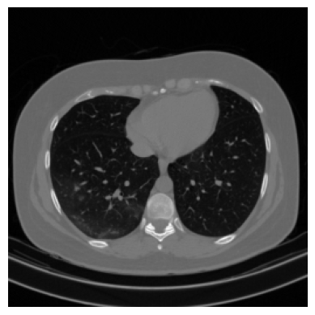

```python
# Visualize sample image
import matplotlib.pyplot as plt

sample_path = "/tmp/curated_data/data/test/covid/P024_132.png"
img = read_and_resize_img(sample_path, image_size=256)
print(img.shape)

plt.imshow(img[0], cmap="gray")
plt.axis("off")
plt.show()
```

#### III. Augmentation

There are various augmentation techniques but we need to make sure that these reflect the variations that we might encounter in real life. That is why we will use Torchio library which is specifically designed for radiology data. Take a look at the augmentation transforms in [here](https://torchio.readthedocs.io/transforms/augmentation.html). You will write a function that applies the following transforms with the desired probability:

- Random Noise with p = .2
- Random Bias Field with p = .2
- Random Ghosting with p = .2
- Random Spike with p = .2
- Random Affine with the parameters of (degrees=10, scales=0., translation=0.)and p = .2

Your function should apply either one of these augmentations and it should apply transformation only in 80% of the time.

NOTE: Torchio requires 4D (channel, width, height, slice) data. So you'll need to expand a dimension while transforming. Don't forget to squeeze it back to original.

Ex: augmentation(data) should return a transformed tensor with a shape of (C, W, H) where C is channel, W is width and H is height.

```python
 mask = []
  #3D to 4D
  #Append the transformations
mask.append(tio.RandomNoise(p=0.2))
mask.append(tio.RandomBiasField(p=0.2))
mask.append(tio.RandomGhosting(p=0.2))
mask.append(tio.RandomSpike(p=0.2))
mask.append(tio.RandomAffine(degrees=10, scales=0., translation=0.,p=0.2))
print(mask[0])
```

```
RandomNoise()
```

```python
# First download torchio
!pip install -q torchio
```

```python
import torchio as tio

def augmentation(data):
  ##### START OF YOUR CODE #####
  #Mask list for the transformations.
  mask = []
  #3D to 4D
  data_4d = data.unsqueeze(0)
  #Append the transformations
  mask.append(tio.RandomNoise(p=0.2))
  mask.append(tio.RandomBiasField(p=0.2))
  mask.append(tio.RandomGhosting(p=0.2))
  mask.append(tio.RandomSpike(p=0.2))
  mask.append(tio.RandomAffine(degrees=10, scales=0., translation=0.,p=0.2))
  #Choose a mask and apply it 0.8 of times.
  if random.random()<0.8:
    num_transformations = random.randint(0, (len(mask) - 1))
    chosen_mask = mask[num_transformations]
    masked_data = chosen_mask(data_4d)
    data_3d = masked_data.squeeze(0)
  else:
    data_3d = data_4d.squeeze(0)
  return data_3d
  ##### END OF YOUR CODE #####
```

```
torch.Size([1, 256, 256])
```

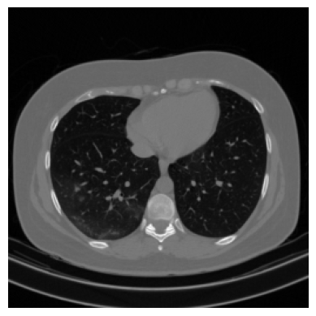

```python
img = read_and_resize_img(sample_path, image_size=256)

aug_img = augmentation(img)
print(aug_img.shape)

plt.imshow(aug_img[0], cmap="gray")
plt.axis("off")
plt.show()
```

#### V. Create CustomDataset class using the functions above. You need to define 2 more functions in this class.

- **__len__(self)** > returns the size of the data
- **__getitem__(self, idx)** > returns a tuple of image and label

NOTE: Do the necessary modifications to use the function arguments as class attributes for a cleaner code.

```python
import os
import numpy as np
import torch
from PIL import Image
import torchio as tio
import torchvision.transforms as T


class CustomDataset(torch.utils.data.Dataset):
  def __init__(self, image_size, data_folder, partition):
    ##### START OF YOUR CODE #####
    self.image_size = image_size
    self.data_folder = data_folder
    self.partition = partition
    ##### END OF YOUR CODE #####

  def __len__(self):
    ##### START OF YOUR CODE #####
    return len(self.img_paths())
    ##### END OF YOUR CODE #####

  def __getitem__(self, idx):
    ##### START OF YOUR CODE #####
    image_path = self.img_paths()[idx] #Take the image path
    image = self.read_and_resize_img(image_path) #Read&resize the image

    image = self.augmentation(image) #Augmentation part
    #Set the label either 1 or 0.
    if self.partition == "normal":
      label = 0
    else:
      label = 1
    return image, torch.tensor(label)
    ##### END OF YOUR CODE #####

  def img_paths(self):
    ##### START OF YOUR CODE #####
    partition_paths = os.path.join(self.data_folder, self.partition)
    normal_path = os.path.join(partition_paths, "normal")
    normal_img_paths = [os.path.join(normal_path, filename) for filename in os.listdir(normal_path)]
    covid_path = os.path.join(partition_paths, "covid")
    covid_img_paths = [os.path.join(covid_path, filename) for filename in os.listdir(covid_path)]
    combined_path = normal_img_paths + covid_img_paths
    random.shuffle(combined_path)
    return combined_path

    ##### END OF YOUR CODE #####

  def read_and_resize_img(self, path):
    ##### START OF YOUR CODE #####
    img = Image.open(path)
    img = img.convert('L')
    transform = T.Compose([T.ToTensor()])
    img = transform(img)
    if img.size(0) != image_size or img.size(1) != image_size or img.size(2) != image_size:
          img = T.functional.resize(img, image_size)
    return img
    ##### END OF YOUR CODE #####

  def augmentation(self, data):
    ##### START OF YOUR CODE #####
    mask = []
    data_4d = data.unsqueeze(0)
    mask.append(tio.RandomNoise(p=0.2))
    mask.append(tio.RandomBiasField(p=0.2))
    mask.append(tio.RandomGhosting(p=0.2))
    mask.append(tio.RandomSpike(p=0.2))
    mask.append(tio.RandomAffine(degrees=10, scales=0., translation=0.,p=0.2))
    if random.random()<0.8:
        num_transformations = random.randint(0, (len(mask) - 1))
        chosen_mask = mask[num_transformations]
        masked_data = chosen_mask(data_4d)
        data_3d = masked_data.squeeze(0)
    else:
      data_3d = data_4d.squeeze(0)
    return data_3d
  ##### END OF YOUR CODE #####
```

```python
from torch.utils.data import DataLoader

image_size = 256
data_dir = "/tmp/curated_data/data"
batch_size = 16

data_dict = {x: CustomDataset(image_size, data_dir, x) for x in ["train", "val", "test"]}
img_data, lab_data = next(iter(data_dict["train"]))
print(img_data.shape, lab_data.shape)

dataloader_dict = {x: DataLoader(data_dict[x], batch_size) for x in ["train", "val", "test"]}
img, lab = next(iter(dataloader_dict["train"]))
print(img.shape, lab.shape)
```

```
torch.Size([1, 256, 256]) torch.Size([])
torch.Size([16, 1, 256, 256]) torch.Size([16])
```

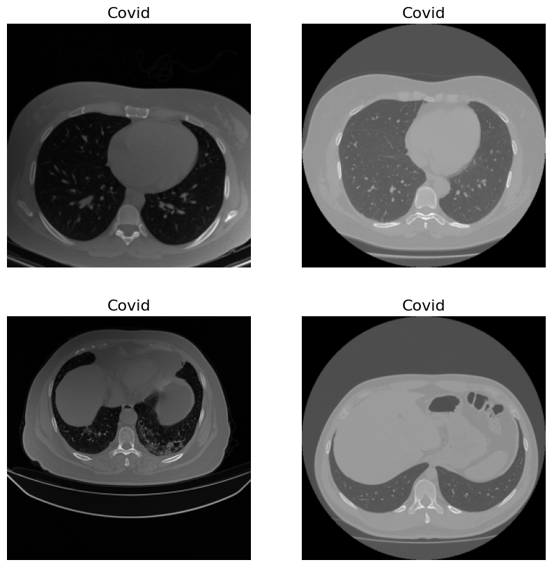

```python
import matplotlib.pyplot as plt

label_dict = {
    0: "Normal",
    1: "Covid"
}
plt.figure(figsize=(10, 10))
for i in range(4):
  plt.subplot(2,2, i+1)
  plt.imshow(img[i, 0], cmap="gray")
  plt.title(label_dict[int(lab[i].item())], fontsize=16)
  plt.axis("off")
plt.show()
```

```python
from google.colab import files
f = files.upload()

# Convert ipynb to html
import subprocess
file0 = list(f.keys())[0]
_ = subprocess.run(["pip", "install", "nbconvert"])
_ = subprocess.run(["jupyter", "nbconvert", file0, "--to", "html"])

# download the html
files.download(file0[:-5]+"html")
```

Upload widget is only available when the cell has been executed in the current browser session. Please rerun this cell to enable.

```
Saving Fatmanur_Yaman_CMPE_49T_Assignment1.ipynb to Fatmanur_Yaman_CMPE_49T_Assignment1.ipynb
```